# Prosper Loan Data Exploration

Greg Clunies

3/18/2018

========================================================

> **Tip**: One of the requirements of this project is that your code follows good formatting techniques, including limiting your lines to 80 characters or less. If you’re using RStudio, go into Preferences > Code > Display to set up a margin line to help you keep track of this guideline!

# Introduction

This report explores a data set containing 113,937 [Prosper](https://www.prosper.com/home/) loans. Prosper specializes is peer-to-peer (P2P) lending, allowing everyday people to both acquire and invest in loans for amounts ranging from $2,000 to $35,000. Prosper provides data to both potential borrowers and investors about their loans, with borrower data focused on the rate they will get on the loan, and investor data focuesed on the estimated return on investment.

The data set has 81 variables associated with each loan, such as: loan amount, borrower rate (i.e., interest rate), loan status, borrower income, borrower employment status, borrower credit history, estimated return for investors, etc. A description of each attribute in the loan dataset is provided [here](https://docs.google.com/spreadsheets/d/1gDyi_L4UvIrLTEC6Wri5nbaMmkGmLQBk-Yx3z0XDEtI/edit#gid=0).

I will approach this analysis from the viewpoint of a potential investor. The data set provides information on both outstanding and closed outloans, so hopefully we can gain some insight on actual versus estimated return on investment. Do prosper loans live up to the hype?

Let’s start by setting up our workbook with the necessary packages, and loading in the dataset to get a sense of the variables available.

```
## [1] 113937     81
```

```
## 'data.frame':    113937 obs. of  81 variables:
##  $ ListingKey                         : Factor w/ 113066 levels "00003546482094282EF90E5",..: 7180 7193 6647 6669 6686 6689 6699 6706 6687 6687 ...
##  $ ListingNumber                      : int  193129 1209647 81716 658116 909464 1074836 750899 768193 1023355 1023355 ...
##  $ ListingCreationDate                : Factor w/ 113064 levels "2005-11-09 20:44:28.847000000",..: 14184 111894 6429 64760 85967 100310 72556 74019 97834 97834 ...
##  $ CreditGrade                        : Factor w/ 9 levels "","A","AA","B",..: 5 1 8 1 1 1 1 1 1 1 ...
##  $ Term                               : int  36 36 36 36 36 60 36 36 36 36 ...
##  $ LoanStatus                         : Factor w/ 12 levels "Cancelled","Chargedoff",..: 3 4 3 4 4 4 4 4 4 4 ...
##  $ ClosedDate                         : Factor w/ 2803 levels "","2005-11-25 00:00:00",..: 1138 1 1263 1 1 1 1 1 1 1 ...
##  $ BorrowerAPR                        : num  0.165 0.12 0.283 0.125 0.246 ...
##  $ BorrowerRate                       : num  0.158 0.092 0.275 0.0974 0.2085 ...
##  $ LenderYield                        : num  0.138 0.082 0.24 0.0874 0.1985 ...
##  $ EstimatedEffectiveYield            : num  NA 0.0796 NA 0.0849 0.1832 ...
##  $ EstimatedLoss                      : num  NA 0.0249 NA 0.0249 0.0925 ...
##  $ EstimatedReturn                    : num  NA 0.0547 NA 0.06 0.0907 ...
##  $ ProsperRating..numeric.            : int  NA 6 NA 6 3 5 2 4 7 7 ...
```

[output cut: 67 more lines]

Looks like the date variables were loaded as factors, let’s convert to POSIXct for ease of use. This is where the [lubridate](http://lubridate.tidyverse.org/index.html) package comes in handy.

```
## [1] "2005-11-09 UTC"
```

```
## [1] "2014-03-10 UTC"
```

Before diving into univariate, bivariate and multivariate analysis. Let’s get an idea of how Propser has done over the time period of the prvided data. Is the Prosper service growing, stagnant, or decreasing over time?

```r
binwidth = 60*60*24*7  # 1-week bin width (in seconds)
date_limits = c(ymd(2005, 11, 09), ymd(2014,03,9))
```

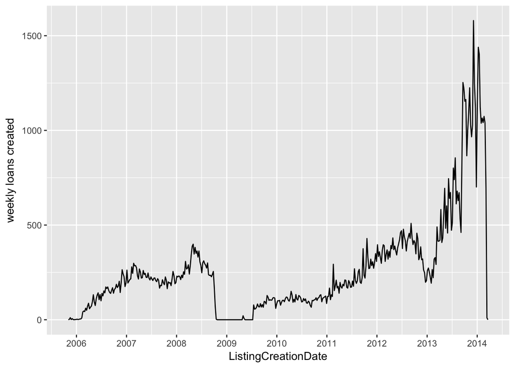

```r
ggplot(data = loan, aes(x = ListingCreationDate)) +
  geom_freqpoly(binwidth = binwidth) +
  scale_x_datetime(breaks = date_breaks("years"), labels = date_format("%Y")) +
  ylab("weekly loans created")
```

From the plot above, we see a drop in loan creation starting roughly around the 3rd quarter of 2008, lasting through quarter 2 in 2009.. what’s going on here?

Some quick research via google and [wikipedia](https://en.wikipedia.org/wiki/Prosper_Marketplace#Cease_and_desist_order) states that in 2008 the SEC found Prosper to be in violation of the Securities Act of 1933 and forced Prosper to stop issuing loans. After some some rounds of litigation, and restructing of the underlying securities (now SEC regulated), Prosper reopened their P2P marketplace to continue issuing loans to borrowers and providing investment opportunities to investors.

For consistency, I will only analyze the data post SEC relaunch (July 2009 onwards) as it seems the data set itself underwent some structural changes (see variable descriptions) during the litigation phase.

```r
loan <- subset(loan, ListingCreationDate >= as.POSIXct("2009-07-01",
                                                       format="%Y-%m-%d"))
```

Since mid 2009 we see a significant increase in issued loans via Prosper Marketplace. We also see what looks to be an increase in volatility in the number of weekly loans created. I wonder what is driving this volatility?

After getting some background infromation on Prosper and a brief look at their history and growth, let’s begin with some univariate analysis.

# Univariate Plots Section

As an investor, and in a sense a lender (via Prosper), I am interested in learning about who borrows money using Prosper. I don’t think its unreasonable to assume that most borrowers are likely using Prosper as an alternative to traditional banks (perhaps due to a lack of eligibilty?), and therefore may pose a risky investment. As a result, I’ll start with their credit score of borrowers as a baseline.

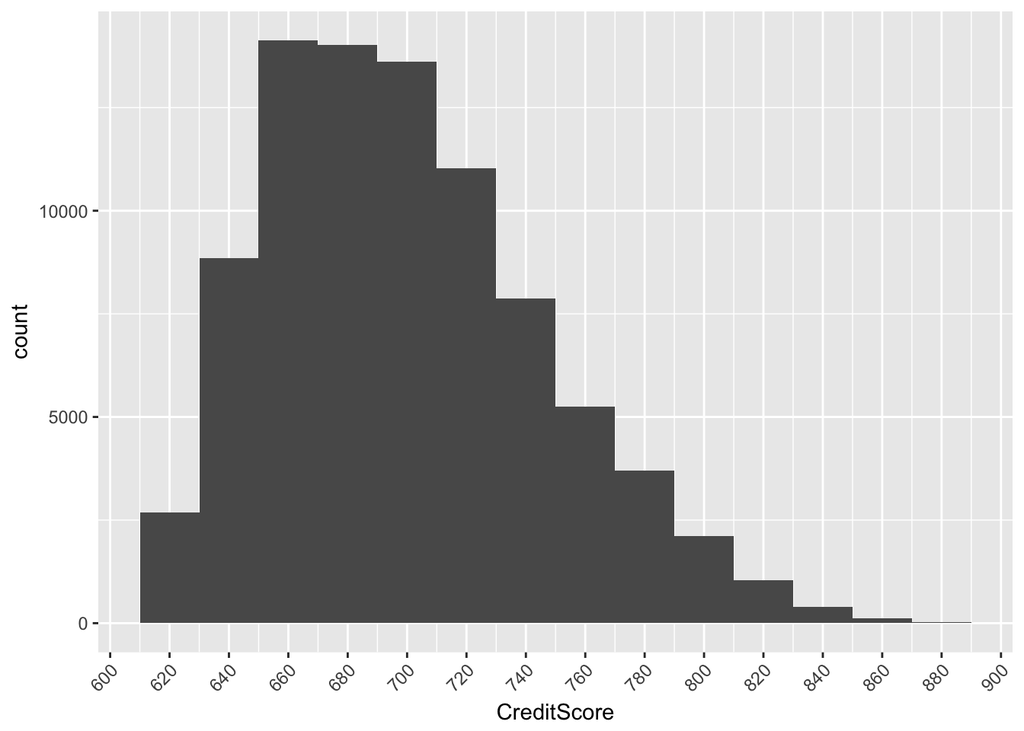

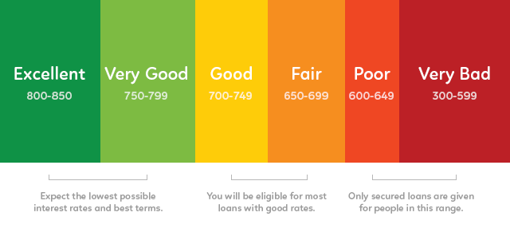

Source: https://www.cafecredit.com/credit-score-range

I have included a figure for showing the corresponding FICO categories above as well. Based on the ranges, it appears most borrowers have a “Fair” credit score. As expected, there are less borrowers with higher credit scores (right skewed distribution).

It would also be good to get a sense of how many credit lines borrowers have, as we may want to avoid borrowers with a lot of liabilities.

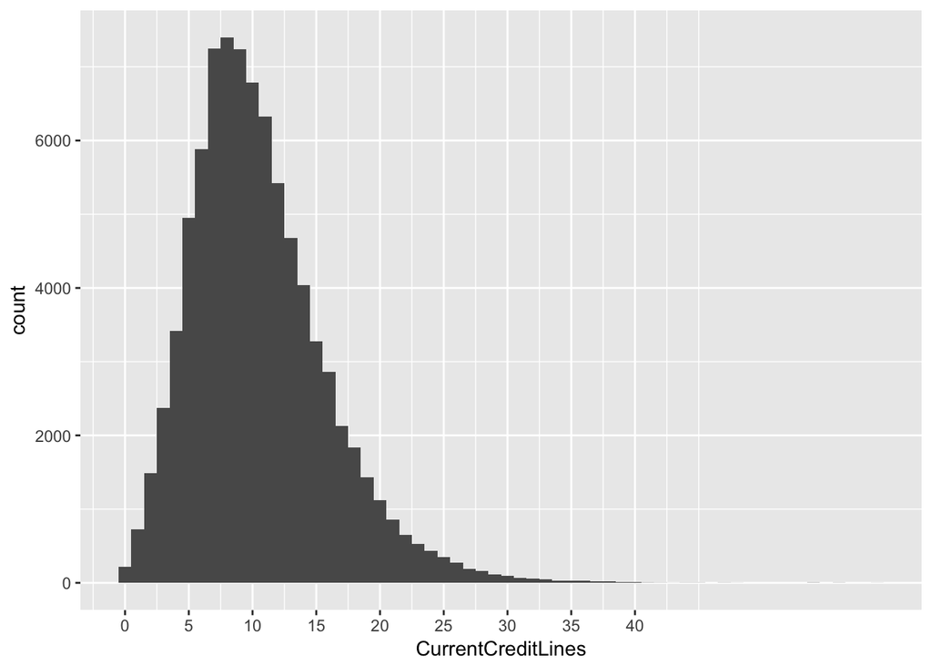

```r
ggplot(data = loan, aes(x = CurrentCreditLines)) +
  geom_histogram(binwidth = 1) +
  scale_x_continuous(breaks = seq(0,40,5))
```

Most borrowers on prosper have around 8 lines of credit. Some borrowers have as much as 40 lines of credit! The distribution is right skewed.

Next, I’ll get an idea of the incomes, employement status, and debt-to-income ratios for borrowers.

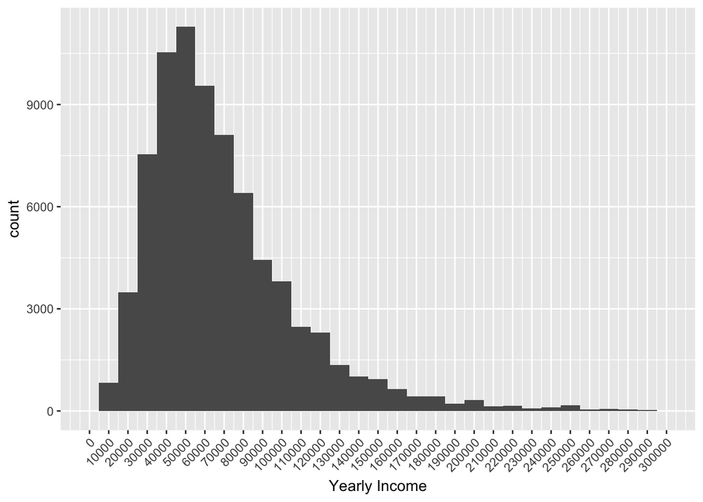

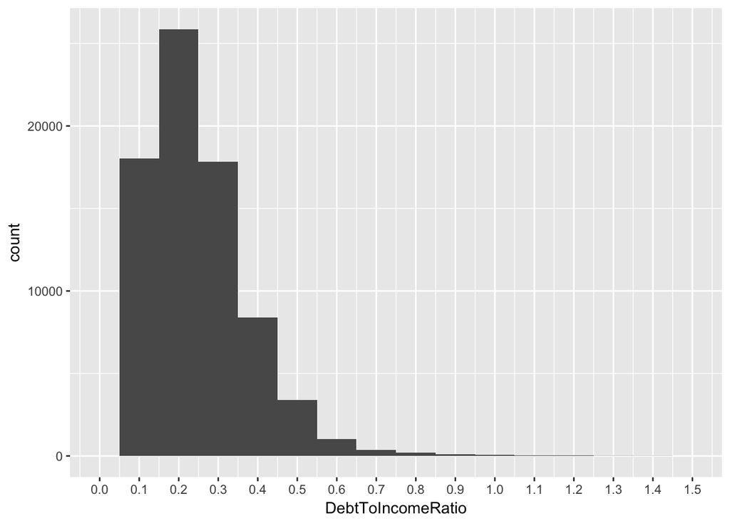

```
##
## False  True
##  7333 77520
```

```
##
##                    Employed     Full-time Not available  Not employed
##             0         67310          7927             0           649
##         Other     Part-time       Retired Self-employed
##          3806           256           367          4538
```

```
##    Min. 1st Qu.  Median    Mean 3rd Qu.    Max.    NA's
##   0.000   0.150   0.220   0.259   0.320  10.010    7296
```

```
##  Employed
## 0.7932542
```

**Note:** Only the loans where a borrower had a verifiable income are shown in the above plots (91% of all loans). Also, incomes greater than $300k are not shown as the tail becomes imperceptibly thin beyond this value. As expected the distribution of incomes is right skewed.

Most borrowers have a income of around $50,000 and a debt to income ratio of 0.2. Most borrowers are also employed (79%).

It might also be helpful to see the status of the loans issued using Prosper since 2009 to get an idea of how they are performing in a general sense. Are a large number of borrowers overdue on their loan payments? Have they defaulted? How many loans have been written off? How many were succesfully completed?

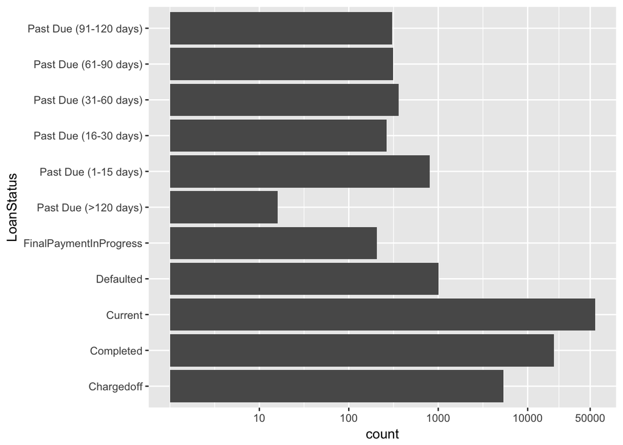

```
##
##              Cancelled             Chargedoff              Completed
##                      0                   5336                  19664
##                Current              Defaulted FinalPaymentInProgress
##                  56576                   1005                    205
##   Past Due (>120 days)   Past Due (1-15 days)  Past Due (16-30 days)
##                     16                    806                    265
##  Past Due (31-60 days)  Past Due (61-90 days) Past Due (91-120 days)
##                    363                    313                    304
```

```
##
##    12    36    60
##  1613 58695 24545
```

Prosper also provides some additional proprietary parameters (Prosper [Scores](https://www.prosper.com/plp/general-prosper_score/) & [Ratings](https://www.prosper.com/plp/invest/prosper-ratings/)) of loan quality to investors. Prosper Scores help estimate the the probability of the loan going bad (going 60+ days past due in first year of loan), whereas the Prosper Rating appears to be a more overall description of loan risk. Remember, both are proprietary parameters provided by Prosper to potential investors. I’ll take a look at them quickly.

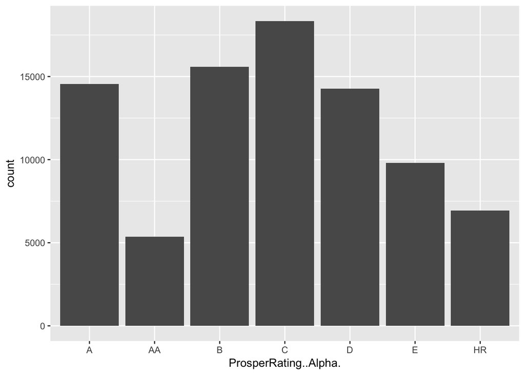

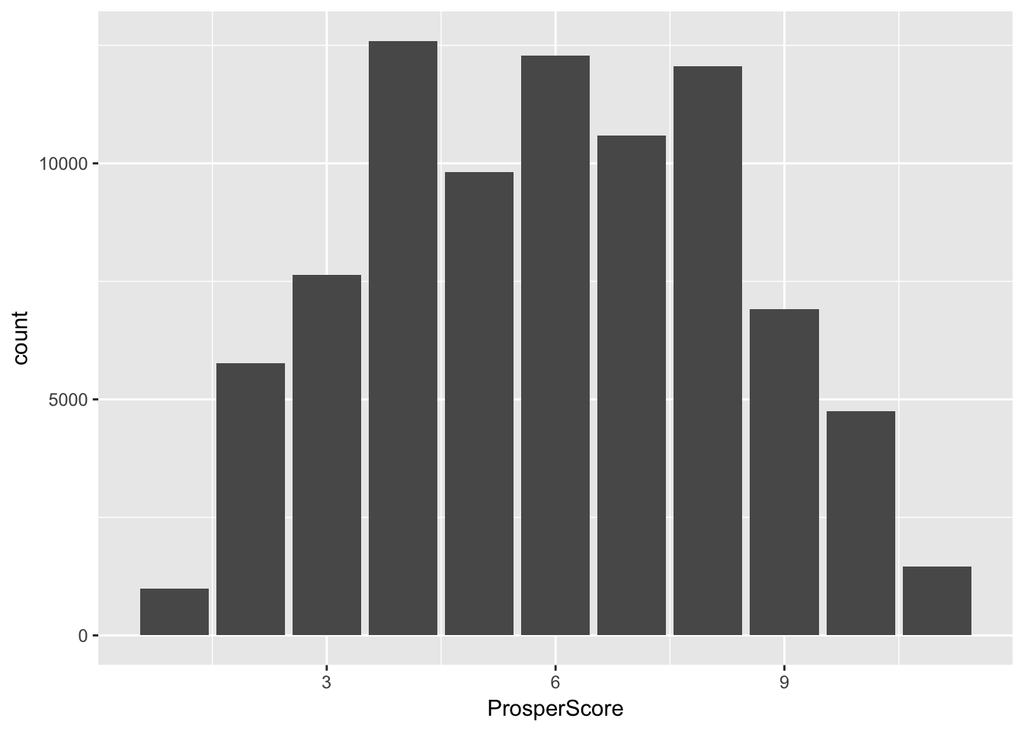

Next, I will take a look at the rates most borrowers get, and the estimated returns and losses for investors.

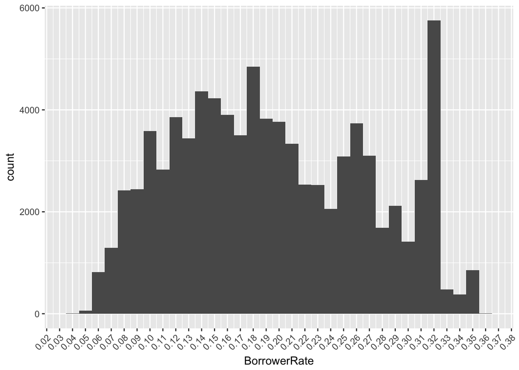

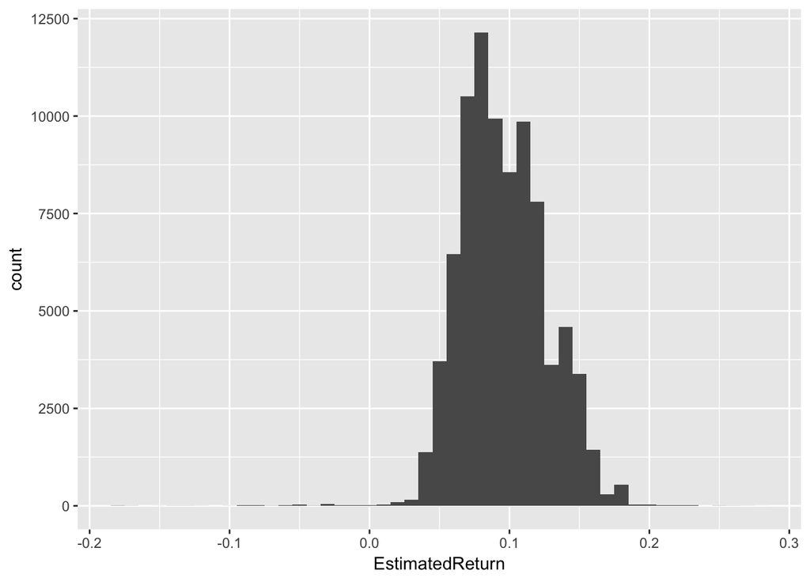

```
##     Min.  1st Qu.   Median     Mean  3rd Qu.     Max.
## -0.18270  0.07408  0.09170  0.09607  0.11660  0.28370
```

It looks like most borrowers get a rate around 0.15 to 0.2 (median 0.1875), but we can see that a substational amount of borrowers get rates around 0.26. This distrubution is definitely not normal. Shockingly, we see that the most common rate for borrowers is 0.32 (32%)!

Although the estimated return for a loan is certainly information I would like when trying to choose one loan over the other. I think it is worth taking a look at actual loan performance. Unfortuantely, Prosper does not make this information available so we need to do a bit of work to tease this out of the data set.

I will use the following formula to calculate the *Actual Return* also known as the cumalative return, $R_c$ ([Source](https://www.fool.com/knowledge-center/annualized-return-vs-cumulative-return.aspx):

$$R_c = (LP_{CustomerPrincipalPayments} + LP_{InterestandFees} +
LP_{CollectionFees} - LoanOriginalAmount)/ LoanOriginalAmount$$

Obviously, we can only assess the loans that are completed (i.e., have a closing date ) for this information to be a true measure of actual loan returns.

[figure not shown]

```r
loan_completed <- loan %>%
  filter(!is.na(ClosedDate))

loan_completed$ActualReturn <- with(loan_completed,
  (LP_CustomerPrincipalPayments + LP_InterestandFees +
     LP_CollectionFees - LoanOriginalAmount)/LoanOriginalAmount)

x <- 0
ggplot(data = loan_completed, aes(x = ActualReturn)) +
  geom_histogram(breaks = seq(-1.0,1.0,0.02), fill="blue", color="black") +
  geom_vline(xintercept = 0, linewidth = 4, linetype = 2, color = "red")
```

```r
# summarize loans that make money
summary(subset(loan_completed, ActualReturn >= 0)$ActualReturn)
```

```
##    Min. 1st Qu.  Median    Mean 3rd Qu.    Max.
## 0.00000 0.07314 0.14853 0.19139 0.27484 1.27108
```

```r
# summarize loans that lose money
summary(subset(loan_completed, ActualReturn < 0)$ActualReturn)
```

```
##      Min.   1st Qu.    Median      Mean   3rd Qu.      Max.
## -1.335543 -0.870506 -0.721707 -0.671794 -0.515325 -0.000001
```

Now this is some useful information! We can see that most loans have positive returns, which is expected otherwise Prosper would not be in business long! However, there are definitely loans that lose money for investors as well. Curiously, when a loan turns out to be a losing bet it more often than not tends to lose **BIG**. Both the positive and negative return loans are right skewed in their resepctive distributions (split by red dashed line).

> **Tip**: Make sure that you leave a blank line between the start / end of each code block and the end / start of your Markdown text so that it is formatted nicely in the knitted text. Note as well that text on consecutive lines is treated as a single space. Make sure you have a blank line between your paragraphs so that they too are formatted for easy readability.

# Univariate Analysis

> **Tip**: Now that you’ve completed your univariate explorations, it’s time to reflect on and summarize what you’ve found. Use the questions below to help you gather your observations and add your own if you have other thoughts!

### What is the structure of your dataset?

Some cleaning was done to allow for easy handling of loan date information (convert to POSIXct). As stated earlier, only loans after 2009 are used in this analysis to ensure structural consistency of the data set.

In addition some variables were added to the data set which now contains records for 84,853 loans (rows) with 82 variables for each loan (columns).

A 83rd variable was also created, but only for the completed loans, which is stored in a separate data frame called `loan_completed`.

### What is/are the main feature(s) of interest in your dataset?

The main features of the dataset include: - Loan date/timing information (e.g., start date, end date) - Borrower information (e.g., credit score, income, etc.) - Loan quality informmation (e.g., Prosper Score, Prosper Rating) - Estimated loan perfromance information for investors (e.g., estimated returns)

### Did you create any new variables from existing variables in the dataset?

Two variables were created to aid in this analysis: 1. CreditScore - midpoint of the credit range the borrower was classified to be within 2. ActualReturns - calculated return for all closed out loans.

These variables will help later during the bivariate and multivariate analysis. Hopefully, they can be used to some light on the type of loans that result in higher returns, and evaluate how well Prosper’s rating and scoring parameter represent true loan perfromance.

### Of the features you investigated, were there any unusual distributions?

First, looking at weekly loans created was surprising as this shed some light on the growth of the Propser P2P marketplace and forced me to further investigate Prosper’s business model. Knowing that the Propser marketplace is regulated by the SEC does provide some more confididence that there is some oversight into the business as a whole. Though this does not mean you can’t lose money!.

Borrower rates showed an unusual distribution. Though partially right skewed, there are some clear spikes at higher rates. This suggests that Prosoper thinks most of it’s borrowers are a higher investment risk. Strangely, we don’t see a similar distibution in the Prosper Rating and Score of loans.

I was also surpised by the distribution of the negtaive ActualReturns (laons that lost money) were right skewed, which suggests that when borrowers stop making loan payments they tend to do so early on in the loan cycle, which leads to a higher loss as a percentage of the original loan value and investment by investors.

# Bivariate Plots Section

> **Tip**: Based on what you saw in the univariate plots, what relationships between variables might be interesting to look at in this section? Don’t limit yourself to relationships between a main output feature and one of the supporting variables. Try to look at relationships between supporting variables as well.

```r
# download shapefile from web
# (comment out 3 lines below after downloading, otherwise code hangs ???)
# download.file("http://www2.census.gov/geo/tiger/GENZ2017/shp/cb_2017_us_state_500k.zip" , # destfile="states_shape_file.zip")
# system("unzip states_shape_file.zip")

library(rgdal)
state_spdf <- readOGR( dsn= getwd() , layer="cb_2017_us_state_500k")
# Look at the info provided with the geospatial object
head(state_spdf@data)
```

```
##   STATEFP  STATENS    AFFGEOID GEOID STUSPS          NAME LSAD
## 0      54 01779805 0400000US54    54     WV West Virginia   00
## 1      17 01779784 0400000US17    17     IL      Illinois   00
## 2      24 01714934 0400000US24    24     MD      Maryland   00
## 3      16 01779783 0400000US16    16     ID         Idaho   00
## 4      50 01779802 0400000US50    50     VT       Vermont   00
## 5      09 01779780 0400000US09    09     CT   Connecticut   00
##          ALAND     AWATER
## 0  62265662566  489840834
## 1 143784114293 6211277447
## 2  25150696145 6980371026
## 3 214048160737 2393355752
## 4  23873457570 1031134839
## 5  12542619303 1815495323
```

```r
summary(state_spdf@data)
```

```
##     STATEFP       STATENS          AFFGEOID      GEOID        STUSPS
##  01     : 1   00068085: 1   0400000US01: 1   01     : 1   AK     : 1
##  02     : 1   00294478: 1   0400000US02: 1   02     : 1   AL     : 1
##  04     : 1   00448508: 1   0400000US04: 1   04     : 1   AR     : 1
##  05     : 1   00481813: 1   0400000US05: 1   05     : 1   AS     : 1
##  06     : 1   00606926: 1   0400000US06: 1   06     : 1   AZ     : 1
##  08     : 1   00662849: 1   0400000US08: 1   08     : 1   CA     : 1
##  (Other):50   (Other) :50   (Other)    :50   (Other):50   (Other):50
##              NAME    LSAD             ALAND             AWATER
##  Alabama       : 1   00:56   102254240128: 1   10264451012 : 1
##  Alaska        : 1           102266092821: 1   1027245114  : 1
##  American Samoa: 1           105833282399: 1   1028643155  : 1
##  Arizona       : 1           106798015774: 1   1031134839  : 1
##  Arkansas      : 1           111904803121: 1   103998746281: 1
##  California    : 1           115881477379: 1   1081293682  : 1
##  (Other)       :50           (Other)     :50   (Other)     :50
```

```r
# Add loan counts to state_spdf
```

# Bivariate Analysis

> **Tip**: As before, summarize what you found in your bivariate explorations here. Use the questions below to guide your discussion.

### Talk about some of the relationships you observed in this part of the investigation. How did the feature(s) of interest vary with other features in the dataset?

### Did you observe any interesting relationships between the other features (not the main feature(s) of interest)?

### What was the strongest relationship you found?

# Multivariate Plots Section

> **Tip**: Now it’s time to put everything together. Based on what you found in the bivariate plots section, create a few multivariate plots to investigate more complex interactions between variables. Make sure that the plots that you create here are justified by the plots you explored in the previous section. If you plan on creating any mathematical models, this is the section where you will do that.

# Multivariate Analysis

### Talk about some of the relationships you observed in this part of the investigation. Were there features that strengthened each other in terms of looking at your feature(s) of interest?

### Were there any interesting or surprising interactions between features?

### OPTIONAL: Did you create any models with your dataset? Discuss the strengths and limitations of your model.

# Final Plots and Summary

> **Tip**: You’ve done a lot of exploration and have built up an understanding of the structure of and relationships between the variables in your dataset. Here, you will select three plots from all of your previous exploration to present here as a summary of some of your most interesting findings. Make sure that you have refined your selected plots for good titling, axis labels (with units), and good aesthetic choices (e.g. color, transparency). After each plot, make sure you justify why you chose each plot by describing what it shows.

### Plot One

### Description One

### Plot Two

### Description Two

### Plot Three

### Description Three

# Reflection

> **Tip**: Here’s the final step! Reflect on the exploration you performed and the insights you found. What were some of the struggles that you went through? What went well? What was surprising? Make sure you include an insight into future work that could be done with the dataset.

> **Tip**: Don’t forget to remove this, and the other **Tip** sections before saving your final work and knitting the final report!